[figure not shown]

# Objective :

To apply knowledge and skills of Python programming and business analytics to organize and analyze real-life data for meaningful insights.

# Executive summary :

Crowdfunding means collecting funds for a project or commercial endeavor by soliciting contributions from a large number of people using an online platform. Our project focuses on Kiva.org, one of the world's most popular crowdfunding platforms.

Kiva.org is a prosocial crowdfunding platform where people from all around the world lend money to people in need. Kiva's purpose is to alleviate poverty in underdeveloped nations by allowing crowd-funded interest-free loans to underprivileged individuals and organizations. Kiva has made $1.63 billion in loans to over 4 million borrowers in 77 countries from over 1.9 million lenders since its inception in 2005. Despite its rapid expansion, Kiva has managed to keep a 96.2 percent repayment rate.

In our project, we are going to predict the status of the loan either 'funded' or 'notfunded' based on different variables(features). We have use two models "Logistic Regression" and "Decision Tree" for data modeling.

# Project motivation/background :

Kiva.org, which was founded in 2005, is one of the largest online crowdfunding platforms in the world, allowing people to lend money to under represented entrepreneurs all around the world. Kiva's objective is to "connect people through loans to alleviate poverty," and it aims to give safe and cheap access to capital in areas where traditional banking services are unavailable, allowing people to become entrepreneurs and create possibilities for themselves and their families.

Kiva serves borrowers and lenders via the internet. Lenders who are willing to invest look through the various profiles of people looking for microcredit based on the loan request and borrower's attributes and invests on them. Kiva does not get any income on the loans it facilitates, and neither do Kiva lenders. Borrowers, on the other hand, pay interest to the financing process's intermediates, known as field partners, who are effectively the ones that carry the majority of the risk.

Kiva is active in 77 underdeveloped countries and collaborates with 304 field partners, according to statistics obtained in March 2015. In comparison to many other lending systems, Kiva stands out for its work with field partners. The field partners' purpose is to help the process along by creating a local presence and advancing funds to the borrowers prior to posting the loan request on the Kiva platform, allowing the borrowers to get a head start on their business.Kiva has made $1.63 billion in loans from over 1.9 million lenders since its inception in 2005. Kiva has managed to keep a 96.2 percent repayment rate. Considering different criteria, Kiva will decide whether to fund the loan to the borrower.

# Data description :

Our data used in this project is obtained from Kiva site. The snapshots of Kiva data are provided in their site “https://www.kiva.org/build/data-snapshots”. We're working with the data in the csv file.Three data tables: loans.csv, lenders.csv, and loans_lenders.csv that maps which lender gives to which project are provided. The target variable used for the prediction is “STATUS” which is a nominal data type also called as the dependent variable.The input variables are the ones which plays prominent role in determining the status of the loan.

loans_lenders Data :  
Variable names and descriptions of lender and loan characteristics:  
LOAN_ID - identification number of the loan.This is unique for each loan.  
LENDERS - list of lenders for a particular loan  
Loans Data :  
Variable names and descriptions of loan characteristics:  
LOAN_ID - identification number of the loan.This is unique for each loan.  
LOAN_NAME - name of the person taking loan  
ORIGINAL_LANGUAGE - language of the borrower  
DESCRIPTION - reason of taking the loan  
DESCRIPTION_TRANSLATED - translated version of the description  
FUNDED_AMOUNT - The amount of the loan already funded.  
LOAN_AMOUNT - the loan amount requested.  
STATUS - status of the loan  
IMAGE_ID - id of image  
VIDEO_ID - id of video  
ACTIVITY_NAME - activity for which loan is taken  
SECTOR_NAME - sector for which loan is taken  
LOAN_USE - reason for which loan is used  
COUNTRY_CODE - code of the borrower country  
COUNTRY_NAME - name of the borrower country  
TOWN_NAME - town of the borrower  
CURRENCY_POLICY - currency policy representing shared or standard  
CURRENCY_EXCHANGE_COVERAGE_RATE - conversion rate of the currency  
CURRENCY - name of the currency  
PARTNER_ID - field partner id  
POSTED_TIME - loan request posted time  
PLANNED_EXPIRATION_TIME - loan expiration time  
DISBURSE_TIME - loan pay out time  
RAISED_TIME - Time at which the loan amount is allocated  
LENDER_TERM - repaying time of loan to the lender  
NUM_LENDERS_TOTAL - total number of lenders for one loan id  
NUM_JOURNAL_ENTRIES - document number of financial transactions  
NUM_BULK_ENTRIES - bulk entry number  
TAGS - tags used to identify the loan request reason  
BORROWER_NAMES - names of the borrowers  
BORROWER_GENDERS - gender of the borrowers  
BORROWER_PICTURED - true/false values  
REPAYMENT_INTERVAL - Period of time granted for repayment, in months.Repayment interval as irregular/monthly/bullet  
DISTRIBUTION_MODEL - loan distribution model  
Lenders data :  
Variable names and descriptions of lender characteristics:  
PERMANENT_NAME - permanent name/unique name of the lender  
DISPLAY_NAME - display name of the lender  
MAIN_PIC_ID - image id of the lender  
CITY - city of the lender  
STATE - state of the lender  
COUNTRY_CODE - country code of the lender  
MEMBER_SINCE - member since id  
PERSONAL_URL - personal webpage of the lender  
OCCUPATION - occupation of the lender  
LOAN_BECAUSE - reason for lending loan  
OTHER_INFO - other information given by lender  
LOAN_PURCHASE_NUM - The number which describes the purchase of the loan  
INVITED_BY-The invited by represents the referred person details  
NUM_INVITED- the num_invited represented as 0 or 1.Number of lenders that responded to a particular loan request.

- The target variable is 'STATUS'.
- The predictor variables we want to include:  
  ORIGINAL_LANGUAGE  
  the logAmount  
  IMAGE_ID  
  SECTOR_NAME  
  COUNTRY_NAME  
  CURRENCY_POLICY  
  CURRENCY_EXCHANGE_COVERAGE_RATE  
  Days we creatd based on the TIME_LENGTH  
  PREDISBURSE  
  LENDER_TERM  
  NUM_JOURNAL_ENTRIES  
  NUM_BULK_ENTRIES  
  REPAYMENT_INTERVAL  
  DISTRIBUTION_MODEL
- The categorical variables used are 'ORIGINAL_LANGUAGE','SECTOR_NAME','COUNTRY_NAME','CURRENCY_POLICY','PREDISBURSE',  
  'REPAYMENT_INTERVAL','DISTRIBUTION_MODEL'.

# Data transformation :

```python
# By default, when you run each cell, only the last output of the codes will show.
# This code makes all outputs of a cell show.
from IPython.core.interactiveshell import InteractiveShell
InteractiveShell.ast_node_interactivity = "all"
```

```python
import pandas as pd
import numpy as np
```

Reading in the three tables.

```python
#reading the tables
lendersdf=pd.read_csv('./kiva_data/lenders.csv')
loansdf=pd.read_csv('./kiva_data/loans.csv')
loanslendersdf=pd.read_csv('./kiva_data/loans_lenders.csv')
```

Displaying the information about each dataframe.

```python
#we use .info() to get the information about each dataset
lendersdf.info()
loansdf.info()
loanslendersdf.info()
```

```
<class 'pandas.core.frame.DataFrame'>
RangeIndex: 1578579 entries, 0 to 1578578
Data columns (total 14 columns):
 #   Column             Non-Null Count    Dtype
---  ------             --------------    -----
 0   PERMANENT_NAME     1578579 non-null  object
 1   DISPLAY_NAME       1576973 non-null  object
 2   MAIN_PIC_ID        517538 non-null   float64
 3   CITY               545446 non-null   object
 4   STATE              510167 non-null   object
 5   COUNTRY_CODE       667850 non-null   object
 6   MEMBER_SINCE       1578579 non-null  int64
 7   PERSONAL_URL       48907 non-null    object
 8   OCCUPATION         337438 non-null   object
 9   LOAN_BECAUSE       152734 non-null   object
```

[output cut: 56 more lines]

Checking for missing values of the loans dataframe.We use sum() to find out the number of missing values.

```python
#checking for missing values using .isnull()
#number of missing values can be found by using .sum()
loansdf.isnull().sum()
```

```
LOAN_ID                                  0
LOAN_NAME                            50389
ORIGINAL_LANGUAGE                    46040
DESCRIPTION                          46269
DESCRIPTION_TRANSLATED              455655
FUNDED_AMOUNT                            0
LOAN_AMOUNT                              0
STATUS                                   0
IMAGE_ID                             46040
VIDEO_ID                           2185897
ACTIVITY_NAME                            0
SECTOR_NAME                              0
LOAN_USE                             46063
COUNTRY_CODE                            36
COUNTRY_NAME                             0
TOWN_NAME                           179089
CURRENCY_POLICY                          0
CURRENCY_EXCHANGE_COVERAGE_RATE     527609
CURRENCY                                 0
PARTNER_ID                               0
POSTED_TIME                              0
PLANNED_EXPIRATION_TIME             371834
DISBURSE_TIME                         4274
RAISED_TIME                         102030
LENDER_TERM                             24
NUM_LENDERS_TOTAL                        0
NUM_JOURNAL_ENTRIES                      0
NUM_BULK_ENTRIES                         0
TAGS                                975998
BORROWER_NAMES                       50389
BORROWER_GENDERS                     46040
BORROWER_PICTURED                    46040
REPAYMENT_INTERVAL                       0
DISTRIBUTION_MODEL                       0
dtype: int64
```

First, we check the dependent variable 'STATUS' in the loans dataframe.We will the unique values of it.

```python
#unique values in the column 'STATUS' in loans dataframe
#we use .unique()
loanStatus=loansdf['STATUS'].unique()
print(loanStatus)
```

```
['funded' 'expired' 'refunded' 'fundRaising']
```

The total observations for each category of 'STATUS'

```python
#we use .value_counts() to get the total values under each category for a variable in dataset
loansdf['STATUS'].value_counts()
```

```
funded         2078544
expired          93435
refunded          9329
fundRaising       5810
Name: STATUS, dtype: int64
```

Our purpose is to build a model that predicts whether a loan can get funded based on loan features. 1) Deleting the records with the category we can ignore.  
2) Recoding the three categories to two categories (funded, notfunded)  
The recoded variable will be our target variable.

Our goal is to create a model that can anticipate the funding process based on the facts found in the data, which includes loan traits and attributes. We'll look at the data and try to extract the funding details, as well as find the attributes in the dataset that can help us come to the conclusion that the loan has been funded, and the remaining unneeded attributes can be removed from the dataset so that the dataset only contains the required attributes.

At this stage, our major goal is to remove any undesirable observations from the loans dataset, such as duplicates or irrelevant ones. During data collection, duplicate observations are the most common. Duplicate data can be created by combining records from multiple locations, collecting data, or receiving data from consumers or multiple lending departments and categories. Because our present data is acquired by Kiva rather than by us, it is preferable to assess the data collection and delete any unneeded data. The removal of redundant or unnecessary data from our collection will be our primary goal immediately. When we see something that isn't relevant to the current problem we're trying to solve, we call it an irrelevant observation. From the loans file, missing data can range from missing sequences, incomplete features, missing files, inadequate information, data input errors, and so on.

We will now delete all records with the status 'fundraising' from our database because they are no longer relevant to our next steps. Because we want to make the modifications to our dataset permanently, we'll use the drop command to ignore the fundraising data by setting it to True. We'll acquire the dataset that doesn't have fundraising status in our loans dataset when we finish the first stage.

We will replace the records of "expired," "refunded," and "notfunded" with "notfunded" because both records transmit the same record facts. We will also change the record name to a common one so that we can analyze the data more thoroughly.

```python
#'funded' suggests the loan is funded
#expired and refunded suggests the loan is not funded
#fundraising can be ignored.

#deleting the fundraising value from 'STATUS'. we use filtering.
completed_Loans= loansdf['STATUS'] != 'fundRaising'
loansdf= loansdf[completed_Loans]

#recoding the categories into two categories
loansdf['STATUS']=loansdf['STATUS'].replace('expired','notfunded')
loansdf['STATUS']=loansdf['STATUS'].replace('refunded','notfunded')

#recodedStatus is target variable.
recodedStatus=loansdf['STATUS'].unique()
print(recodedStatus)

#checking the table
loansdf.head()
```

```
['funded' 'notfunded']
```

|  | LOAN_ID | LOAN_NAME | ORIGINAL_LANGUAGE | DESCRIPTION | DESCRIPTION_TRANSLATED | FUNDED_AMOUNT | LOAN_AMOUNT | STATUS | IMAGE_ID | VIDEO_ID | ... | LENDER_TERM | NUM_LENDERS_TOTAL | NUM_JOURNAL_ENTRIES | NUM_BULK_ENTRIES | TAGS | BORROWER_NAMES | BORROWER_GENDERS | BORROWER_PICTURED | REPAYMENT_INTERVAL | DISTRIBUTION_MODEL |
| --- | --- | --- | --- | --- | --- | --- | --- | --- | --- | --- | --- | --- | --- | --- | --- | --- | --- | --- | --- | --- | --- |
| 0 | 304819 | Estrella De Luz Group | Spanish | Este grupo se llama "Estrella de luz" está ubi... | This group is called “Estrella de Luz” (Star o... | 2600.0 | 2600.0 | funded | 785529.0 | NaN | ... | 6.0 | 6 | 1 | 1 | NaN | MARISOL, ANGELICA, EVA, JUANA, ISABEL, MARIA P... | female, female, female, female, female, female... | true, true, true, true, true, true, true, true... | monthly | field_partner |
| 1 | 1361590 | Grace | English | Grace is an honest, humble, and hard-working p... | Grace is an honest, humble, and hard-working p... | 600.0 | 600.0 | funded | 2614927.0 | NaN | ... | 20.0 | 21 | 2 | 1 | #Parent, #Woman-Owned Business | Grace | female | true | monthly | field_partner |
| 2 | 1776536 | Ligaya | English | Ligaya is a hardworking micro-entrepreneur.<br... | Ligaya is a hardworking micro-entrepreneur.<br... | 200.0 | 200.0 | funded | 3173512.0 | NaN | ... | 13.0 | 8 | 2 | 1 | #Eco-friendly, #Health and Sanitation | Ligaya | female | true | monthly | field_partner |
| 3 | 213423 | Phorn Vann's Group | English | Mrs. Phorn V., who is 61 years old, is the gro... | NaN | 650.0 | 650.0 | funded | 565776.0 | NaN | ... | 14.0 | 19 | 1 | 1 | NaN | Phorn, Bunthorn, Moeurn, Mi, Yim | female, male, female, female, female | true, true, true, true, true | bullet | field_partner |
| 4 | 410154 | Grace | English | Grace is 55 years old and married with 4 child... | NaN | 625.0 | 625.0 | funded | 1059131.0 | NaN | ... | 14.0 | 17 | 1 | 1 | NaN | Grace | female | true | monthly | field_partner |

5 rows × 34 columns

Examining the variable 'LOAN_AMOUNT'.  
1) Checking the distribution. What is the value of outliers if we use 3*IQR to define?  
2) Removing the outliers.  
3) Creating a new variable by taking log of this variable.

The interquartile range concept will be utilized now, for analyzing the distribution and the dispersion of data, we will use the IQR concept and will split the data as required with respect to quartiles. The observations which fall outside the mentioned quartiles are removed. We will remove the outliers by dropping the data which is above the upper range and below the lower range. The log function is utilized for creating a new variable by taking the log of the ‘LOAN AMOUNT’.

```python
#describe the 'LOAN_AMOUNT' to check the distribution
loansdf['LOAN_AMOUNT'].describe()
Q3=np.quantile(loansdf['LOAN_AMOUNT'] , 0.75)
Q1=np.quantile(loansdf['LOAN_AMOUNT'] , 0.25)

#IQR
IQR = (Q3 - Q1)
print(IQR)

lowerVal = (Q1 - (3 * IQR))
upperVal = (Q3 + (3 * IQR))

#remove the outliers
loansdf.drop(loansdf[ (loansdf['LOAN_AMOUNT'] > upperVal) | (loansdf['LOAN_AMOUNT'] < lowerVal) ].index ,
             inplace=True)
#taking log and creating new variable
loansdf['LOAN_AMOUNT_LOG']=np.log(loansdf['LOAN_AMOUNT'])
loansdf['LOAN_AMOUNT_LOG'].value_counts()
loansdf.head()
```

```
count    2.181308e+06
mean     8.114910e+02
std      1.672586e+03
min      2.500000e+01
25%      2.750000e+02
50%      5.000000e+02
75%      9.500000e+02
max      5.000000e+05
Name: LOAN_AMOUNT, dtype: float64
```

```
675.0
```

```
5.298317    104147
5.703782     96485
6.214608     91905
5.416100     82884
4.828314     81117
             ...
7.981050      1202
7.872836      1174
7.853605      1141
7.910224      1135
7.928406      1135
Name: LOAN_AMOUNT_LOG, Length: 119, dtype: int64
```

|  | LOAN_ID | LOAN_NAME | ORIGINAL_LANGUAGE | DESCRIPTION | DESCRIPTION_TRANSLATED | FUNDED_AMOUNT | LOAN_AMOUNT | STATUS | IMAGE_ID | VIDEO_ID | ... | NUM_LENDERS_TOTAL | NUM_JOURNAL_ENTRIES | NUM_BULK_ENTRIES | TAGS | BORROWER_NAMES | BORROWER_GENDERS | BORROWER_PICTURED | REPAYMENT_INTERVAL | DISTRIBUTION_MODEL | LOAN_AMOUNT_LOG |
| --- | --- | --- | --- | --- | --- | --- | --- | --- | --- | --- | --- | --- | --- | --- | --- | --- | --- | --- | --- | --- | --- |
| 0 | 304819 | Estrella De Luz Group | Spanish | Este grupo se llama "Estrella de luz" está ubi... | This group is called “Estrella de Luz” (Star o... | 2600.0 | 2600.0 | funded | 785529.0 | NaN | ... | 6 | 1 | 1 | NaN | MARISOL, ANGELICA, EVA, JUANA, ISABEL, MARIA P... | female, female, female, female, female, female... | true, true, true, true, true, true, true, true... | monthly | field_partner | 7.863267 |
| 1 | 1361590 | Grace | English | Grace is an honest, humble, and hard-working p... | Grace is an honest, humble, and hard-working p... | 600.0 | 600.0 | funded | 2614927.0 | NaN | ... | 21 | 2 | 1 | #Parent, #Woman-Owned Business | Grace | female | true | monthly | field_partner | 6.396930 |
| 2 | 1776536 | Ligaya | English | Ligaya is a hardworking micro-entrepreneur.<br... | Ligaya is a hardworking micro-entrepreneur.<br... | 200.0 | 200.0 | funded | 3173512.0 | NaN | ... | 8 | 2 | 1 | #Eco-friendly, #Health and Sanitation | Ligaya | female | true | monthly | field_partner | 5.298317 |
| 3 | 213423 | Phorn Vann's Group | English | Mrs. Phorn V., who is 61 years old, is the gro... | NaN | 650.0 | 650.0 | funded | 565776.0 | NaN | ... | 19 | 1 | 1 | NaN | Phorn, Bunthorn, Moeurn, Mi, Yim | female, male, female, female, female | true, true, true, true, true | bullet | field_partner | 6.476972 |
| 4 | 410154 | Grace | English | Grace is 55 years old and married with 4 child... | NaN | 625.0 | 625.0 | funded | 1059131.0 | NaN | ... | 17 | 1 | 1 | NaN | Grace | female | true | monthly | field_partner | 6.437752 |

5 rows × 35 columns

Observing the missing value results from 3rd step i.e checking the total number of missing values from all the variables. We will be observing the outcome for variables 'COUNTRY_CODE' and 'COUNTRY_NAME' and drop the necessary ones.

We observe that 'COUNTRY_NAME' has 0 missing values and 'COUNTRY_CODE' has 36 missing values. We will be dropping the Country code as it has missing values and use the Country name data for further processing.

```python
#from Q3 output, we can observe that 'COUNTRY_CODE' has 36 missing values
#'COUNTRY_NAME' has 0 missing values
#hence, we drop the 'COUNTRY_CODE'
loansdf.drop('COUNTRY_CODE',axis=1,inplace=True)
#we can find if COUNTRY_CODE is dropped from the loans dataframe by using .info()
loansdf.info()
```

```
<class 'pandas.core.frame.DataFrame'>
Int64Index: 2092429 entries, 0 to 2187117
Data columns (total 34 columns):
 #   Column                           Dtype
---  ------                           -----
 0   LOAN_ID                          int64
 1   LOAN_NAME                        object
 2   ORIGINAL_LANGUAGE                object
 3   DESCRIPTION                      object
 4   DESCRIPTION_TRANSLATED           object
 5   FUNDED_AMOUNT                    float64
 6   LOAN_AMOUNT                      float64
 7   STATUS                           object
 8   IMAGE_ID                         float64
 9   VIDEO_ID                         float64
```

[output cut: 26 more lines]

Finding the number of missing values in variables 'IMAGE_ID', 'VIDEO_ID' and 'LOAN_USE'.

In the dataset 'VIDEO_ID' has too many missing values so we will be dropping it for higher accurate results.  
We can recode 'IMAGE_ID' variable to indicate whether the loan has image, all missing values indicate there is no image hence we can code them as 0,and if images are present we can code them as 1.The respective records are filled with 1 and 0 for the dataset reading convenience. The records counts are once again analyzed with respect to 'IMAGE_ID' by the help of value_counts function.

```python
#finding the number of missing values in variables 'IMAGE_ID', 'VIDEO_ID' and 'LOAN_USE'
loansdf['IMAGE_ID'].isnull().sum()
loansdf['VIDEO_ID'].isnull().sum()
loansdf['LOAN_USE'].isnull().sum()

#fill the missing value of 'IMAGE_ID' with 0, others with 1.
loansdf['IMAGE_ID'] = loansdf['IMAGE_ID'].apply(lambda x: 1 if x>0 else 0)
loansdf['IMAGE_ID'].unique()

#VIDEO_ID has many missing values
#drop VIDEO_ID and LOAN_USE
loansdf.drop('VIDEO_ID',axis=1,inplace=True)
loansdf.drop('LOAN_USE',axis=1,inplace=True)

#checking the information
#we can check if the LOAN_USE and VIDEO_ID are dropped in the output below.
loansdf.info()
```

```
44296
```

```
2091973
```

```
44313
```

```
array([1, 0])
```

```
<class 'pandas.core.frame.DataFrame'>
Int64Index: 2092429 entries, 0 to 2187117
Data columns (total 32 columns):
 #   Column                           Dtype
---  ------                           -----
 0   LOAN_ID                          int64
 1   LOAN_NAME                        object
 2   ORIGINAL_LANGUAGE                object
 3   DESCRIPTION                      object
 4   DESCRIPTION_TRANSLATED           object
 5   FUNDED_AMOUNT                    float64
 6   LOAN_AMOUNT                      float64
 7   STATUS                           object
 8   IMAGE_ID                         int64
 9   ACTIVITY_NAME                    object
```

[output cut: 24 more lines]

Creating a new variable 'TIME_LENGTH' that is the difference between 'POSTED_TIME' and 'RAISED_TIME'.

A new variable called 'TIME_LENGTH' is created which is the difference between 'RAISED_TIME' and 'POSTED_TIME' is created with the help of pd.to_datetime function, the function utilizes the date and time on which the data is created.

```python
#creating a new variable 'TIME_LENGTH' which is the difference between RAISED_TIME and POSTED_TIME.
loansdf['TIME_LENGTH'] = pd.to_datetime(loansdf['RAISED_TIME']) - pd.to_datetime(loansdf['POSTED_TIME'])
loansdf['TIME_LENGTH'].dtype
loansdf['TIME_LENGTH']
#checking if the new variable is added in the table
loansdf.head()
```

```
dtype('<m8[ns]')
```

```
0         10 days 08:21:35
1         35 days 08:45:35
2         11 days 00:29:31
3         34 days 07:11:28
4         14 days 02:01:23
                ...
2187113    8 days 06:09:21
2187114   26 days 11:30:00
2187115   32 days 19:03:34
2187116    0 days 14:57:09
2187117    1 days 22:33:52
Name: TIME_LENGTH, Length: 2092429, dtype: timedelta64[ns]
```

|  | LOAN_ID | LOAN_NAME | ORIGINAL_LANGUAGE | DESCRIPTION | DESCRIPTION_TRANSLATED | FUNDED_AMOUNT | LOAN_AMOUNT | STATUS | IMAGE_ID | ACTIVITY_NAME | ... | NUM_JOURNAL_ENTRIES | NUM_BULK_ENTRIES | TAGS | BORROWER_NAMES | BORROWER_GENDERS | BORROWER_PICTURED | REPAYMENT_INTERVAL | DISTRIBUTION_MODEL | LOAN_AMOUNT_LOG | TIME_LENGTH |
| --- | --- | --- | --- | --- | --- | --- | --- | --- | --- | --- | --- | --- | --- | --- | --- | --- | --- | --- | --- | --- | --- |
| 0 | 304819 | Estrella De Luz Group | Spanish | Este grupo se llama "Estrella de luz" está ubi... | This group is called “Estrella de Luz” (Star o... | 2600.0 | 2600.0 | funded | 1 | Retail | ... | 1 | 1 | NaN | MARISOL, ANGELICA, EVA, JUANA, ISABEL, MARIA P... | female, female, female, female, female, female... | true, true, true, true, true, true, true, true... | monthly | field_partner | 7.863267 | 10 days 08:21:35 |
| 1 | 1361590 | Grace | English | Grace is an honest, humble, and hard-working p... | Grace is an honest, humble, and hard-working p... | 600.0 | 600.0 | funded | 1 | Farming | ... | 2 | 1 | #Parent, #Woman-Owned Business | Grace | female | true | monthly | field_partner | 6.396930 | 35 days 08:45:35 |
| 2 | 1776536 | Ligaya | English | Ligaya is a hardworking micro-entrepreneur.<br... | Ligaya is a hardworking micro-entrepreneur.<br... | 200.0 | 200.0 | funded | 1 | Personal Housing Expenses | ... | 2 | 1 | #Eco-friendly, #Health and Sanitation | Ligaya | female | true | monthly | field_partner | 5.298317 | 11 days 00:29:31 |
| 3 | 213423 | Phorn Vann's Group | English | Mrs. Phorn V., who is 61 years old, is the gro... | NaN | 650.0 | 650.0 | funded | 1 | Farming | ... | 1 | 1 | NaN | Phorn, Bunthorn, Moeurn, Mi, Yim | female, male, female, female, female | true, true, true, true, true | bullet | field_partner | 6.476972 | 34 days 07:11:28 |
| 4 | 410154 | Grace | English | Grace is 55 years old and married with 4 child... | NaN | 625.0 | 625.0 | funded | 1 | Dairy | ... | 1 | 1 | NaN | Grace | female | true | monthly | field_partner | 6.437752 | 14 days 02:01:23 |

5 rows × 33 columns

Finding the difference between 'POSTED_TIME' and 'DISBURSE_TIME'. Creating a new variable 'PREDISBURSE' if the 'DISBURSE_TIME' is before 'POSTED_TIME'.

'POSTED_TIME' and 'DISBURSE_TIME' are the variables which describes the posted time details and disburse time details with respect to datetime function of panda. The 'PREDISBURSE' variable is created with respect to 'POSTED_TIME' and 'DISBURSE_TIME'. The 'PREDISBURSE' variable has the values where the 'DISBURSE_TIME' values less than 'POSTED_TIME' values.

```python
#creating a new variable 'PREDISBURSE' if the 'DISBURSE_TIME' is before 'POSTED_TIME'. Filling it with 1 else with 0.
loansdf.loc[pd.to_datetime(loansdf['DISBURSE_TIME']) < pd.to_datetime(loansdf['POSTED_TIME']), 'PREDISBURSE' ]=1
loansdf.loc[pd.to_datetime(loansdf['DISBURSE_TIME']) >= pd.to_datetime(loansdf['POSTED_TIME']), 'PREDISBURSE' ]=0

#checking the values for 1 and 0 category of PREDISBURSE variable.
loansdf['PREDISBURSE'].value_counts()

#checking the table
loansdf.head()
```

```
1.0    1925726
0.0     165117
Name: PREDISBURSE, dtype: int64
```

|  | LOAN_ID | LOAN_NAME | ORIGINAL_LANGUAGE | DESCRIPTION | DESCRIPTION_TRANSLATED | FUNDED_AMOUNT | LOAN_AMOUNT | STATUS | IMAGE_ID | ACTIVITY_NAME | ... | NUM_BULK_ENTRIES | TAGS | BORROWER_NAMES | BORROWER_GENDERS | BORROWER_PICTURED | REPAYMENT_INTERVAL | DISTRIBUTION_MODEL | LOAN_AMOUNT_LOG | TIME_LENGTH | PREDISBURSE |
| --- | --- | --- | --- | --- | --- | --- | --- | --- | --- | --- | --- | --- | --- | --- | --- | --- | --- | --- | --- | --- | --- |
| 0 | 304819 | Estrella De Luz Group | Spanish | Este grupo se llama "Estrella de luz" está ubi... | This group is called “Estrella de Luz” (Star o... | 2600.0 | 2600.0 | funded | 1 | Retail | ... | 1 | NaN | MARISOL, ANGELICA, EVA, JUANA, ISABEL, MARIA P... | female, female, female, female, female, female... | true, true, true, true, true, true, true, true... | monthly | field_partner | 7.863267 | 10 days 08:21:35 | 1.0 |
| 1 | 1361590 | Grace | English | Grace is an honest, humble, and hard-working p... | Grace is an honest, humble, and hard-working p... | 600.0 | 600.0 | funded | 1 | Farming | ... | 1 | #Parent, #Woman-Owned Business | Grace | female | true | monthly | field_partner | 6.396930 | 35 days 08:45:35 | 1.0 |
| 2 | 1776536 | Ligaya | English | Ligaya is a hardworking micro-entrepreneur.<br... | Ligaya is a hardworking micro-entrepreneur.<br... | 200.0 | 200.0 | funded | 1 | Personal Housing Expenses | ... | 1 | #Eco-friendly, #Health and Sanitation | Ligaya | female | true | monthly | field_partner | 5.298317 | 11 days 00:29:31 | 1.0 |
| 3 | 213423 | Phorn Vann's Group | English | Mrs. Phorn V., who is 61 years old, is the gro... | NaN | 650.0 | 650.0 | funded | 1 | Farming | ... | 1 | NaN | Phorn, Bunthorn, Moeurn, Mi, Yim | female, male, female, female, female | true, true, true, true, true | bullet | field_partner | 6.476972 | 34 days 07:11:28 | 1.0 |
| 4 | 410154 | Grace | English | Grace is 55 years old and married with 4 child... | NaN | 625.0 | 625.0 | funded | 1 | Dairy | ... | 1 | NaN | Grace | female | true | monthly | field_partner | 6.437752 | 14 days 02:01:23 | 1.0 |

5 rows × 34 columns

Examining variable 'CURRENCY_EXCHANGE_COVERAGE_RATE'. Checking the unique values for this variable and the missing value count?  
Before we rush to replace missing values with mode, we ask the question: is the missing value actually missing or is it something else? We then read the policies on Kiva about exchange coverage. For instance, a lender gives 25 in US dollars and it changes to 250 in another currency. But when the money is repaid at 250 in the other currency, it only exchanges to 20 US dollars. The CURRENCY_EXCHANGE_COVERAGE_RATE measures how much such loss will be covered by the field partners. Some would cover 10% or 20%. So, it is more likely that the missing values indicating the loan does not have any coverage. So, it's more likely means 0.  
Replacing the missing value with 0.

To analyze the CURRENCY_EXCHANGE_COVERAGE_RATE', the missing values and unique values are found out from the dataset. The CURRENCY_EXCHANGE_COVERAGE_RATE variable measures how much loss will be covered by the field partners during the currency conversion. Some conversion would result in percentages such as 10% or 20%. So, it is indicated that the missing values indicating the loan does not have any coverage. So, it's more likely means 0. The missing values are replaced with 0 so that the currency conversion rates which will be having least effect on the dataset.

```python
#describing the variable 'CURRENCY_EXCHANGE_COVERAGE_RATE'
loansdf['CURRENCY_EXCHANGE_COVERAGE_RATE'].describe()

#finding the unique values
loansdf['CURRENCY_EXCHANGE_COVERAGE_RATE'].unique()

#finding the number of missing values
loansdf['CURRENCY_EXCHANGE_COVERAGE_RATE'].isnull().sum()

#filling the missing values with 0
loansdf['CURRENCY_EXCHANGE_COVERAGE_RATE'].fillna(0, inplace =True)

#checking the unique values to see if 0 is replaced in the missing values.
loansdf['CURRENCY_EXCHANGE_COVERAGE_RATE'].unique()
loansdf['CURRENCY_EXCHANGE_COVERAGE_RATE'].value_counts()
```

```
count    1.596457e+06
mean     1.039931e-01
std      4.218881e-02
min      0.000000e+00
25%      1.000000e-01
50%      1.000000e-01
75%      1.000000e-01
max      2.000000e-01
Name: CURRENCY_EXCHANGE_COVERAGE_RATE, dtype: float64
```

```
array([nan, 0.1, 0.2, 0. ])
```

```
495972
```

```
array([0. , 0.1, 0.2])
```

```
0.1    1309759
0.0     607447
0.2     175223
Name: CURRENCY_EXCHANGE_COVERAGE_RATE, dtype: int64
```

# Exploratory Data analysis :

Take a look at the data after we have done the 12 steps above. We will continue the preparation. Check the unique values of 'ACTIVITY_NAME' and 'SECTOR_NAME'. You may notice that there are many more activities than sectors and Sector is higher-level categorization of loans. We can choose one of them. To keep the results easier to read. We can keep sector name. 'LOAN_NAME' seems irrelevant to whether a loan is funded. We have not learned how to process 'DESCRIPTION' and 'DESCRIPTION_TRANSLATED'. 'FUNDED_AMOUNT' is the amount that actually raised at the end. Most times it is the same as 'LOAN_AMOUNT'. After doing similar analysis with every variable, we decide to keep only the following variables in the final analysis:  
LOAN_ID  
ORIGINAL_LANGUAGE  
LOAN_AMOUNT (and the logAmount variable we created)  
STATUS  
IMAGE_ID (the one we coded to 0/1)  
SECTOR_NAME  
COUNTRY_NAME  
CURRENCY_POLICY  
CURRENCY_EXCHANGE_COVERAGE_RATE (the one we tranfromed)  
POSTED_TIME (and the TIME_LENGTH we created)  
DISBURSE_TIME (and the PREDISBURSE we created)  
RAISED_TIME  
LENDER_TERM  
NUM_JOURNAL_ENTRIES  
NUM_BULK_ENTRIES  
REPAYMENT_INTERVAL  
DISTRIBUTION_MODEL

Creating a copy of the dataset that only contains the variables listed above.

```python
#selected variables for final analysis
variable_List=['LOAN_ID','ORIGINAL_LANGUAGE','LOAN_AMOUNT','LOAN_AMOUNT_LOG','STATUS','IMAGE_ID','SECTOR_NAME',
               'COUNTRY_NAME','CURRENCY_POLICY','CURRENCY_EXCHANGE_COVERAGE_RATE','POSTED_TIME','TIME_LENGTH',
               'DISBURSE_TIME','PREDISBURSE','RAISED_TIME','LENDER_TERM','NUM_JOURNAL_ENTRIES','NUM_BULK_ENTRIES',
               'REPAYMENT_INTERVAL','DISTRIBUTION_MODEL']
#dataframe
loansAnalysisDf= loansdf[variable_List]
#checking the table
loansAnalysisDf.head()
```

|  | LOAN_ID | ORIGINAL_LANGUAGE | LOAN_AMOUNT | LOAN_AMOUNT_LOG | STATUS | IMAGE_ID | SECTOR_NAME | COUNTRY_NAME | CURRENCY_POLICY | CURRENCY_EXCHANGE_COVERAGE_RATE | POSTED_TIME | TIME_LENGTH | DISBURSE_TIME | PREDISBURSE | RAISED_TIME | LENDER_TERM | NUM_JOURNAL_ENTRIES | NUM_BULK_ENTRIES | REPAYMENT_INTERVAL | DISTRIBUTION_MODEL |
| --- | --- | --- | --- | --- | --- | --- | --- | --- | --- | --- | --- | --- | --- | --- | --- | --- | --- | --- | --- | --- |
| 0 | 304819 | Spanish | 2600.0 | 7.863267 | funded | 1 | Retail | Mexico | standard | 0.0 | 2011-06-03 19:14:41.000 +0000 | 10 days 08:21:35 | 2011-05-31 07:00:00.000 +0000 | 1.0 | 2011-06-14 03:36:16.000 +0000 | 6.0 | 1 | 1 | monthly | field_partner |
| 1 | 1361590 | English | 600.0 | 6.396930 | funded | 1 | Agriculture | Kenya | shared | 0.1 | 2017-08-21 12:19:10.000 +0000 | 35 days 08:45:35 | 2017-08-18 07:00:00.000 +0000 | 1.0 | 2017-09-25 21:04:45.000 +0000 | 20.0 | 2 | 1 | monthly | field_partner |
| 2 | 1776536 | English | 200.0 | 5.298317 | funded | 1 | Housing | Philippines | shared | 0.1 | 2019-06-10 00:59:43.000 +0000 | 11 days 00:29:31 | 2019-06-05 07:00:00.000 +0000 | 1.0 | 2019-06-21 01:29:14.000 +0000 | 13.0 | 2 | 1 | monthly | field_partner |
| 3 | 213423 | English | 650.0 | 6.476972 | funded | 1 | Agriculture | Cambodia | shared | 0.2 | 2010-07-08 08:19:17.000 +0000 | 34 days 07:11:28 | 2010-06-23 07:00:00.000 +0000 | 1.0 | 2010-08-11 15:30:45.000 +0000 | 14.0 | 1 | 1 | bullet | field_partner |
| 4 | 410154 | English | 625.0 | 6.437752 | funded | 1 | Agriculture | Kenya | shared | 0.2 | 2012-03-28 12:13:33.000 +0000 | 14 days 02:01:23 | 2012-03-02 08:00:00.000 +0000 | 1.0 | 2012-04-11 14:14:56.000 +0000 | 14.0 | 1 | 1 | monthly | field_partner |

Next we start to explore the data. We import matplotlib. Making two histograms for 'LOAN_AMOUNT' and 'logAMount'.

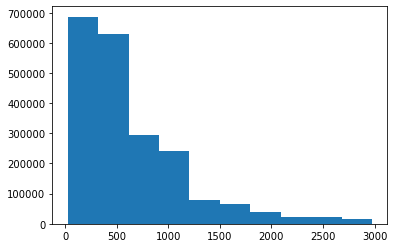

```python
#importing matplotlib
import matplotlib.pyplot as plot

#histogram for 'LOAN_AMOUNT'
plot.hist(loansdf['LOAN_AMOUNT'])
```

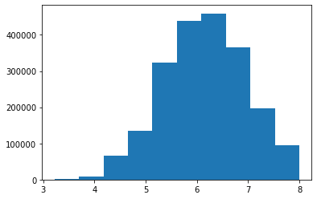

```python
#histogram for logAmount which I defined as 'LOAN_AMOUNT_LOG'
plot.hist(loansdf['LOAN_AMOUNT_LOG'])
# Observation : the skewed distribution of LOAN_AMOUNT has been smoothed out.
```

Observations :

- Looking at the two histograms of the "LOAN_AMOUNT" and "LOAN_AMOUNT_LOG" , we can observe that the skewed distribution of LOAN_AMOUNT has been smoothed out.

What is the total loan amount in each sector? Creating a bar chart to demonstrate.

```
SECTOR_NAME
Agriculture     362748975.0
Arts             27446075.0
Clothing         80164825.0
Construction     19158925.0
Education        58065075.0
Name: LOAN_AMOUNT, dtype: float64
```

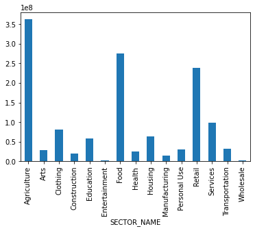

```python
#grouping 'LOAN_AMOUNT' by each sector.
AmountPerSector = loansAnalysisDf.groupby('SECTOR_NAME')['LOAN_AMOUNT'].sum()
AmountPerSector.head()

#bar chart to demonstrate total loan amount in each sector.
AmountPerSector.plot(kind = 'bar')
```

Observations :

- The sectors taken into consideration are "Agriculture" , "Arts", "Clothing", "Construction", "Education", "Entertainment", "Food", "Health", "Housing", "Manufacturing", "Personal Use", "Retail", "Services", "Transportation","Wholesale".
- The x-axis represents the "SECTOR_NAME" and y-axis represents the total loan amount.
- Agriculture sector has the highest loan amount in total comparatively.
- Food sector has the second highest loan amount in total comparatively.
- Entertainment and Wholesale sectors are having the lowest loan amounts.

What is the total number of loans in each country? Creating a bar chart to demonstrate.

```
COUNTRY_NAME
Afghanistan     2335
Albania         5497
Armenia        14491
Azerbaijan     10150
Belize           219
Name: LOAN_ID, dtype: int64
```

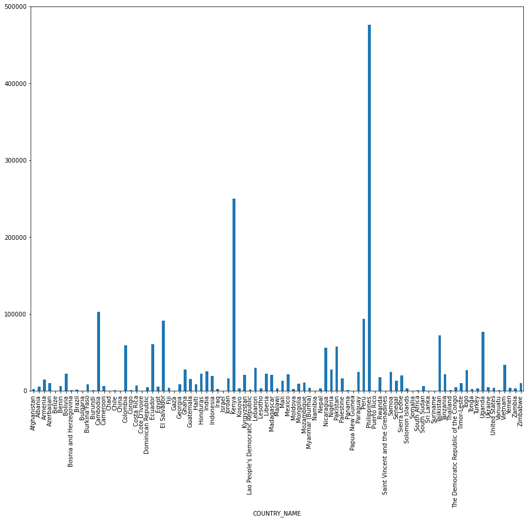

```python
#grouping the total number of loans by each country
loansPerCountry=loansAnalysisDf.groupby('COUNTRY_NAME')['LOAN_ID'].count()
loansPerCountry.head()

#bar chart to demonstrate the total number of loans in each country
loansPerCountry.plot(kind = 'bar', figsize =(15,12))
```

Observations :

- The x-axis represents the "COUNTRY_NAME" and y-axis represents the total number of loans.
- Phillippines has the highest number of loans comparatively.
- Kenya has the 2nd highest number of loans.

Change the POSTED_TIME to DateTimeIndex and creating a new variable 'Year' using the year of POSTED_TIME.  
What is the total number of loans in each year? Creating a line graph to demonstrate.

|  | LOAN_ID | ORIGINAL_LANGUAGE | LOAN_AMOUNT | LOAN_AMOUNT_LOG | STATUS | IMAGE_ID | SECTOR_NAME | COUNTRY_NAME | CURRENCY_POLICY | CURRENCY_EXCHANGE_COVERAGE_RATE | ... | TIME_LENGTH | DISBURSE_TIME | PREDISBURSE | RAISED_TIME | LENDER_TERM | NUM_JOURNAL_ENTRIES | NUM_BULK_ENTRIES | REPAYMENT_INTERVAL | DISTRIBUTION_MODEL | Year |
| --- | --- | --- | --- | --- | --- | --- | --- | --- | --- | --- | --- | --- | --- | --- | --- | --- | --- | --- | --- | --- | --- |
| 0 | 304819 | Spanish | 2600.0 | 7.863267 | funded | 1 | Retail | Mexico | standard | 0.0 | ... | 10 days 08:21:35 | 2011-05-31 07:00:00.000 +0000 | 1.0 | 2011-06-14 03:36:16.000 +0000 | 6.0 | 1 | 1 | monthly | field_partner | 2011 |
| 1 | 1361590 | English | 600.0 | 6.396930 | funded | 1 | Agriculture | Kenya | shared | 0.1 | ... | 35 days 08:45:35 | 2017-08-18 07:00:00.000 +0000 | 1.0 | 2017-09-25 21:04:45.000 +0000 | 20.0 | 2 | 1 | monthly | field_partner | 2017 |
| 2 | 1776536 | English | 200.0 | 5.298317 | funded | 1 | Housing | Philippines | shared | 0.1 | ... | 11 days 00:29:31 | 2019-06-05 07:00:00.000 +0000 | 1.0 | 2019-06-21 01:29:14.000 +0000 | 13.0 | 2 | 1 | monthly | field_partner | 2019 |
| 3 | 213423 | English | 650.0 | 6.476972 | funded | 1 | Agriculture | Cambodia | shared | 0.2 | ... | 34 days 07:11:28 | 2010-06-23 07:00:00.000 +0000 | 1.0 | 2010-08-11 15:30:45.000 +0000 | 14.0 | 1 | 1 | bullet | field_partner | 2010 |
| 4 | 410154 | English | 625.0 | 6.437752 | funded | 1 | Agriculture | Kenya | shared | 0.2 | ... | 14 days 02:01:23 | 2012-03-02 08:00:00.000 +0000 | 1.0 | 2012-04-11 14:14:56.000 +0000 | 14.0 | 1 | 1 | monthly | field_partner | 2012 |

5 rows × 21 columns

```
Year
2006     3200
2007    26265
2008    49954
2009    79583
2010    90138
Name: LOAN_ID, dtype: int64
```

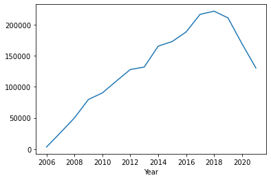

```python
#extracting the year from the POSTED_TIME variable by using DateTimeIndex.
loansAnalysisDf['Year']= pd.DatetimeIndex(loansAnalysisDf['POSTED_TIME']).year
loansAnalysisDf.head()

#grouping the total number of loans by year
loansPerYear= loansAnalysisDf.groupby('Year')['LOAN_ID'].count()
loansPerYear.head()

#we use plot function to demonstrate using a line graph
loansPerYear.plot()
```

Observations :

- Line graph representing the total number of loans in each year.
- The x-axis represents the "Year" and the y-axis represents the total number of loans.
- Around the year 2018, the total number of loans are high and then decreased eventually.

Creating a pivot table to show the average loan amount in each sector each year.

```python
#creating a pivot table to show average loan amount in each sector and each year
loansAnalysisDf.pivot_table('LOAN_AMOUNT',index= 'SECTOR_NAME' , columns ='Year')
```

| Year SECTOR_NAME | 2006 | 2007 | 2008 | 2009 | 2010 | 2011 | 2012 | 2013 | 2014 | 2015 | 2016 | 2017 | 2018 | 2019 | 2020 | 2021 |
| --- | --- | --- | --- | --- | --- | --- | --- | --- | --- | --- | --- | --- | --- | --- | --- | --- |
| Agriculture | 677.455919 | 657.880235 | 684.617722 | 623.594413 | 678.098313 | 721.580157 | 764.921505 | 784.610301 | 710.890633 | 692.998049 | 654.891644 | 634.365077 | 638.312252 | 641.168366 | 533.840443 | 514.573910 |
| Arts | 765.441176 | 556.600877 | 594.340278 | 602.074167 | 737.452420 | 745.825751 | 822.846524 | 708.797554 | 726.123110 | 673.768835 | 639.175187 | 568.633703 | 605.140598 | 723.251998 | 780.572560 | 798.478836 |
| Clothing | 622.483221 | 646.504950 | 682.180233 | 708.049691 | 810.285639 | 812.513982 | 806.195974 | 779.448352 | 727.256545 | 765.992578 | 773.964771 | 751.634396 | 707.910490 | 746.540881 | 683.967112 | 679.472828 |
| Construction | 784.405941 | 730.501618 | 723.112892 | 725.808538 | 751.904880 | 808.087460 | 816.363636 | 832.622774 | 798.184912 | 795.549417 | 831.099935 | 753.264418 | 755.033784 | 837.999460 | 826.621297 | 840.914352 |
| Education | NaN | 794.642857 | 725.274725 | 666.281139 | 674.962121 | 751.921182 | 860.717309 | 857.643714 | 797.358823 | 878.200633 | 834.667050 | 846.851251 | 800.955204 | 778.835596 | 660.697207 | 356.643912 |
| Entertainment | 603.571429 | 531.250000 | 681.770833 | 681.500000 | 636.285714 | 801.954733 | 762.500000 | 812.931034 | 859.566327 | 863.425926 | 883.210784 | 987.008734 | 879.015544 | 881.250000 | 890.476190 | 798.148148 |
| Food | 647.490157 | 595.012937 | 645.766043 | 594.631202 | 647.141493 | 642.240619 | 648.798015 | 643.258057 | 641.785714 | 610.653760 | 615.656124 | 591.633768 | 586.867919 | 614.770576 | 530.509988 | 532.770931 |
| Health | 809.722222 | 714.716312 | 768.494624 | 717.414530 | 764.544808 | 766.472393 | 789.650229 | 912.354167 | 950.224359 | 856.627517 | 832.403759 | 823.549853 | 853.683460 | 823.819041 | 695.913819 | 686.017135 |
| Housing | 497.619048 | 787.557078 | 631.327160 | 608.928571 | 631.899763 | 744.884707 | 850.195122 | 859.677858 | 661.019399 | 751.556973 | 623.098599 | 534.126626 | 574.562354 | 355.497300 | 510.843721 | 471.656579 |
| Manufacturing | 876.190476 | 616.530612 | 726.793558 | 670.545746 | 743.929110 | 826.202091 | 845.851805 | 803.423849 | 731.741097 | 728.960964 | 699.875622 | 636.758837 | 650.751685 | 718.838939 | 627.807102 | 663.151261 |
| Personal Use | NaN | NaN | 746.153846 | 644.179104 | 697.666025 | 737.875817 | 788.401342 | 724.211449 | 529.979420 | 444.361989 | 349.416185 | 294.110319 | 351.096421 | 283.993123 | 253.967643 | 221.802904 |
| Retail | 662.877698 | 623.515683 | 691.455414 | 618.487384 | 650.325903 | 699.755453 | 679.337690 | 657.246254 | 618.527521 | 571.719380 | 561.685924 | 563.980374 | 574.041141 | 618.165944 | 492.503917 | 483.013335 |
| Services | 736.238532 | 647.101310 | 706.189457 | 746.038588 | 765.898531 | 802.365713 | 825.746151 | 784.132039 | 747.411047 | 733.736279 | 705.279056 | 682.342026 | 664.005483 | 720.331824 | 742.198436 | 739.880000 |
| Transportation | 935.795455 | 692.133132 | 713.596774 | 636.237133 | 672.727933 | 741.246883 | 700.107685 | 730.416355 | 604.249881 | 641.660939 | 602.621745 | 562.821603 | 573.966942 | 615.539514 | 581.886045 | 584.538376 |
| Wholesale | NaN | 645.185185 | 775.104603 | 813.472222 | 779.938272 | 888.250000 | 942.625000 | 1096.262887 | 1135.472973 | 1050.265957 | 809.731544 | 836.526946 | 803.968254 | 865.789474 | 863.271605 | 940.833333 |

Getting the number of days in the TIME_LENGTH variable we created and creating a new variable 'Days'using it.  
Creating a scatterplot of 'LOAN_AMOUNT' and 'Days'.

|  | LOAN_ID | ORIGINAL_LANGUAGE | LOAN_AMOUNT | LOAN_AMOUNT_LOG | STATUS | IMAGE_ID | SECTOR_NAME | COUNTRY_NAME | CURRENCY_POLICY | CURRENCY_EXCHANGE_COVERAGE_RATE | ... | DISBURSE_TIME | PREDISBURSE | RAISED_TIME | LENDER_TERM | NUM_JOURNAL_ENTRIES | NUM_BULK_ENTRIES | REPAYMENT_INTERVAL | DISTRIBUTION_MODEL | Year | Days |
| --- | --- | --- | --- | --- | --- | --- | --- | --- | --- | --- | --- | --- | --- | --- | --- | --- | --- | --- | --- | --- | --- |
| 0 | 304819 | Spanish | 2600.0 | 7.863267 | funded | 1 | Retail | Mexico | standard | 0.0 | ... | 2011-05-31 07:00:00.000 +0000 | 1.0 | 2011-06-14 03:36:16.000 +0000 | 6.0 | 1 | 1 | monthly | field_partner | 2011 | 10.0 |
| 1 | 1361590 | English | 600.0 | 6.396930 | funded | 1 | Agriculture | Kenya | shared | 0.1 | ... | 2017-08-18 07:00:00.000 +0000 | 1.0 | 2017-09-25 21:04:45.000 +0000 | 20.0 | 2 | 1 | monthly | field_partner | 2017 | 35.0 |
| 2 | 1776536 | English | 200.0 | 5.298317 | funded | 1 | Housing | Philippines | shared | 0.1 | ... | 2019-06-05 07:00:00.000 +0000 | 1.0 | 2019-06-21 01:29:14.000 +0000 | 13.0 | 2 | 1 | monthly | field_partner | 2019 | 11.0 |
| 3 | 213423 | English | 650.0 | 6.476972 | funded | 1 | Agriculture | Cambodia | shared | 0.2 | ... | 2010-06-23 07:00:00.000 +0000 | 1.0 | 2010-08-11 15:30:45.000 +0000 | 14.0 | 1 | 1 | bullet | field_partner | 2010 | 34.0 |
| 4 | 410154 | English | 625.0 | 6.437752 | funded | 1 | Agriculture | Kenya | shared | 0.2 | ... | 2012-03-02 08:00:00.000 +0000 | 1.0 | 2012-04-11 14:14:56.000 +0000 | 14.0 | 1 | 1 | monthly | field_partner | 2012 | 14.0 |

5 rows × 22 columns

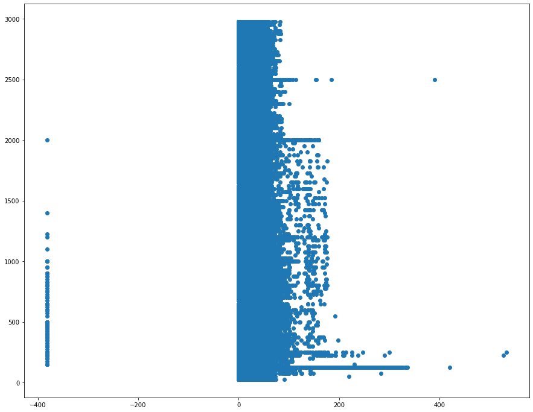

```python
#created new variable 'Days'
#extracting number of days from 'TIME_LENGTH' variable. we have used dt to get the days from the 'TIME_LENGTH'.
loansAnalysisDf['Days'] = loansAnalysisDf['TIME_LENGTH'].dt.days
loansAnalysisDf.head()

#scatter plot of 'LOAN_AMOUNT' and 'Days' to analyze the relationship between the variables
plot.figure(figsize =(15,12))
plot.scatter(loansAnalysisDf['Days'],loansAnalysisDf['LOAN_AMOUNT'])
```

Creating a scatterplot of 'LOAN_AMOUNT' and 'LENDER_TERM'.

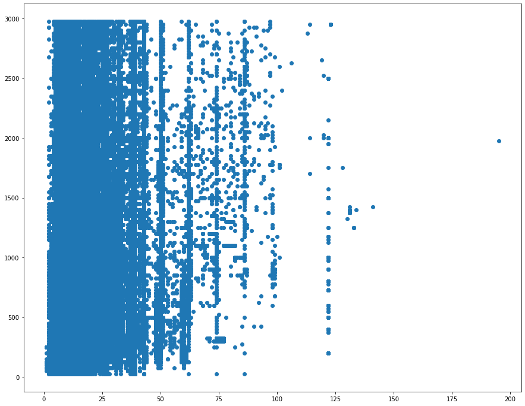

```python
#scatter plot of 'LOAN_AMOUNT' and 'LENDER_TERM'
plot.figure(figsize =(15,12))
plot.scatter(loansAnalysisDf['LENDER_TERM'],loansAnalysisDf['LOAN_AMOUNT'])
```

Observations:

- Scatter plot is created for "LOAN_AMOUNT" and "LENDER_TERM"
- from the above scatter plot, we can see that there is no relationship between the two variables 'LOAN_AMOUNT' and 'LENDER_TERM'.